# Notebook

### Web Information Retrieval and Data Mining - Assignment 3

```
Student: de Quincey, Martin (1007047)
```

#### Answer 1.1, Baseline (4p)

- Dense network, at least 3 layers, shaped like a pyramid
  - Last layer: 10 nodes, sigmoid.
  - Loss: categorical cross-entropy. Metric: accuracy
- No preprocessing, regularization. Get at least 70% accuracy.
- Explain design decisions. Discuss performance.
  - Does it overfit (large/growing gap between loss and val_loss)?

[output not shown]

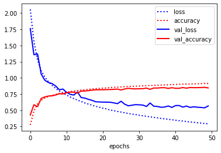

```
Model: "sequential_2"
_________________________________________________________________
Layer (type)                 Output Shape              Param #
=================================================================
reshape_2 (Reshape)          (None, 3072)              0
_________________________________________________________________
dense_4 (Dense)              (None, 1400)              4302200
_________________________________________________________________
dense_5 (Dense)              (None, 600)               840600
_________________________________________________________________
dense_6 (Dense)              (None, 40)                24040
_________________________________________________________________
dense_7 (Dense)              (None, 10)                410
=================================================================
Total params: 5,167,250
Trainable params: 5,167,250
Non-trainable params: 0
_________________________________________________________________
None
def build_model_1_1():
    # We first create a sequential model
    model = models.Sequential()
    # We add a first input layer
    # Since the data is 32 x 32 RGB, the shape is 32 x 32 x 3 = 3072
    # We flatten this in the first layer to create a model
    model.add(layers.Reshape((3072,), input_shape=(32,32,3)))

    # Now we start with the actual weights and such
    model.add(layers.Dense(1400, activation='relu', ))
    model.add(layers.Dense(600, activation='relu', ))
    model.add(layers.Dense(40, activation='relu', ))

    # We of course end with a dense softmax layer,
    # since we are doing classification. 10 nodes, since we have 10 labels.
    model.add(layers.Dense(10, activation='softmax'))

    # We use rmsprop as optimizer, because this is done in other places too.
    # We of course use categorical crossentropy for categorical data.
    # And we use accuracy as our metric, since that is we are graded on (< 70%).
    model.compile(optimizer=optimizers.Adagrad(lr=0.01),
                  loss='categorical_crossentropy',
                  metrics=['accuracy'])

    # We finally return the model
    return model
```

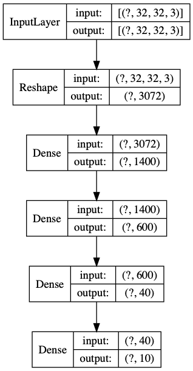

#### Answer 1.2, Preprocess (2p)

- Convert images to greyscale, other preprocessing optional.
  - Input shape should be (32,32,1)
- Explain design decisions. Is it better? Why (not)?
  - Color information is likely not so useful for classification. Greyscale makes the network smaller, less parameters to learn, less likely to overfit.

[output not shown]

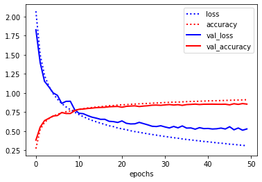

```
Model: "sequential_3"
_________________________________________________________________
Layer (type)                 Output Shape              Param #
=================================================================
reshape_3 (Reshape)          (None, 1024)              0
_________________________________________________________________
dense_8 (Dense)              (None, 1400)              1435000
_________________________________________________________________
dense_9 (Dense)              (None, 600)               840600
_________________________________________________________________
dense_10 (Dense)             (None, 40)                24040
_________________________________________________________________
dense_11 (Dense)             (None, 10)                410
=================================================================
Total params: 2,300,050
Trainable params: 2,300,050
Non-trainable params: 0
_________________________________________________________________
None
def build_model_1_2():
    # We first create a sequential model
    model = models.Sequential()
    # We add a first input layer
    # Since the data is 32 x 32 RGB, the shape is 32 x 32 = 3072
    # We flatten this in the first layer to create a model
    model.add(layers.Reshape((1024,), input_shape=(32,32,1)))

    # Now we start with the actual weights and such
    model.add(layers.Dense(1400, activation='relu', ))
    model.add(layers.Dense(600, activation='relu', ))
    model.add(layers.Dense(40, activation='relu', ))

    # We of course end with a dense softmax layer,
    # since we are doing classification. 10 nodes, since we have 10 labels.
    model.add(layers.Dense(10, activation='softmax'))

    # We use rmsprop as optimizer, because this is done in other places too.
    # We of course use categorical crossentropy for categorical data.
    # And we use accuracy as our metric, since that is we are graded on (< 70%).
    model.compile(optimizer=optimizers.Adagrad(lr=0.01),
                  loss='categorical_crossentropy',
                  metrics=['accuracy'])

    # We finally return the model
    return model
```

#### Answer 1.3, Tune (4p)

- Regularize the model. What works best?
  - Should consider batch normalization, dropout, l1/l2 regularization (or Nesterov)
- Tune other hyperparameters (e.g. learning rate, batch size,...) as you see fit.
  - At least consider tuning learning rate, ideally also momentum, decay, other optimizers
- Explain your findings and final design decisions. Discuss the results.
  - Should be better, at least it shouldn't overfit

[output not shown]

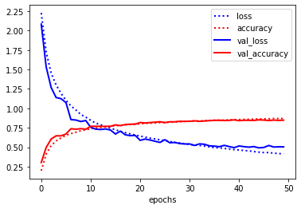

```
def build_model_1_3():
    # We first create a sequential model
    model = models.Sequential()
    # We add a first input layer
    # Since the data is 32 x 32 Grey, the shape is 32 x 32 = 1024
    # We flatten this in the first layer to create a model
    model.add(layers.Reshape((1024,), input_shape=(32,32,1)))

    # Now we start with the actual weights and such
    model.add(layers.Dense(1400, activation='relu', ))
    #model.add(layers.BatchNormalization())
    model.add(layers.Dropout(0.075))
    model.add(layers.Dense(600, activation='relu', ))
    #model.add(layers.BatchNormalization())
    model.add(layers.Dropout(0.125))
    model.add(layers.Dense(40, activation='relu', ))
    model.add(layers.Dropout(0.2))
    model.add(layers.BatchNormalization())

    # We of course end with a dense softmax layer,
    # since we are doing classification. 10 nodes, since we have 10 labels.
    model.add(layers.Dense(10, activation='softmax'))

    # We use rmsprop as optimizer, because this is done in other places too.
    # We of course use categorical crossentropy for categorical data.
    # And we use accuracy as our metric, since that is we are graded on (< 70%).
    model.compile(optimizer=optimizers.Adagrad(lr=0.01),
                  loss='categorical_crossentropy',
                  metrics=['accuracy'])

    # We finally return the model
    return model
```

#### Answer 2.1, ConvNet (7p)

- Build a sequential ConvNet, get at least 90% accuracy.
  - Conv2D layers, input shape (32,32,1)
  - Consider using blocks of Conv2D layers with maxpooling in between
  - Use zero-padding in Conv2D layers because the images are small
  - At least one dense hidden layer and dense output layer (sigmoid)
  - Consider adding batch normalization, dropout
  - Consider small dropout rates in beginning, larger dropout rates later in network
  - Consider other optimizers and tuning learning rate, momentum,...
- Explain what you did and why (800 chars). Is it working well?
  - Should be quite elaborate and sensible

[output not shown]

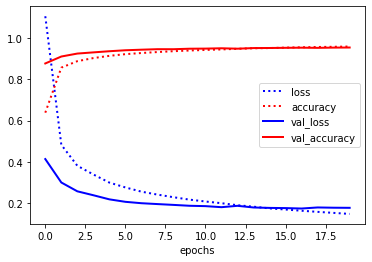

```
Model: "sequential_9"
_________________________________________________________________
Layer (type)                 Output Shape              Param #
=================================================================
conv2d_6 (Conv2D)            (None, 32, 32, 32)        320
_________________________________________________________________
batch_normalization_8 (Batch (None, 32, 32, 32)        128
_________________________________________________________________
conv2d_7 (Conv2D)            (None, 32, 32, 32)        9248
_________________________________________________________________
batch_normalization_9 (Batch (None, 32, 32, 32)        128
_________________________________________________________________
max_pooling2d_3 (MaxPooling2 (None, 16, 16, 32)        0
_________________________________________________________________
dropout_8 (Dropout)          (None, 16, 16, 32)        0
_________________________________________________________________
conv2d_8 (Conv2D)            (None, 16, 16, 64)        32832
_________________________________________________________________
batch_normalization_10 (Batc (None, 16, 16, 64)        256
_________________________________________________________________
conv2d_9 (Conv2D)            (None, 16, 16, 64)        65600
_________________________________________________________________
batch_normalization_11 (Batc (None, 16, 16, 64)        256
_________________________________________________________________
max_pooling2d_4 (MaxPooling2 (None, 8, 8, 64)          0
_________________________________________________________________
dropout_9 (Dropout)          (None, 8, 8, 64)          0
_________________________________________________________________
conv2d_10 (Conv2D)           (None, 8, 8, 128)         131200
_________________________________________________________________
batch_normalization_12 (Batc (None, 8, 8, 128)         512
_________________________________________________________________
max_pooling2d_5 (MaxPooling2 (None, 4, 4, 128)         0
_________________________________________________________________
dropout_10 (Dropout)         (None, 4, 4, 128)         0
_________________________________________________________________
conv2d_11 (Conv2D)           (None, 4, 4, 256)         819456
_________________________________________________________________
batch_normalization_13 (Batc (None, 4, 4, 256)         1024
_________________________________________________________________
```

[output cut: 59 more lines]

```
    model.add(layers.Dense(128, activation='relu'))
    model.add(layers.Dropout(0.4))
    model.add(layers.BatchNormalization())

    model.add(layers.Dense(25, activation='relu'))

    # Output layer
    model.add(layers.Dense(10, activation='softmax'))

    # Compile
    model.compile(optimizer=optimizers.Adagrad(lr=0.01),
              loss='categorical_crossentropy',
              metrics=['accuracy'])

    return model
```

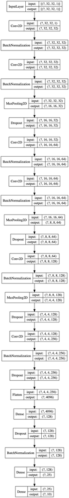

#### Answer 2.2, Data Augmentation (3p)

- Augment the preprocessed training data.
  - Use small variations (small shifts up-down, left-right) of flips becasue the images are small
  - Large shifts and rotations distort the image too much
- Explain what you did and why. Discuss the performance of the model.

[output not shown]

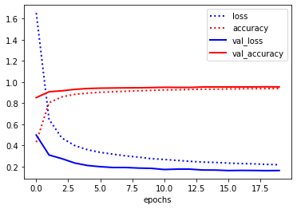

```
train_datagen = ImageDataGenerator(
    width_shift_range=0.1,
    height_shift_range=0.1,
    zca_whitening=True,
    zoom_range=[1, 1.25])
```

#### Answer 3.1, Misclassifications (2p)

[output not shown]

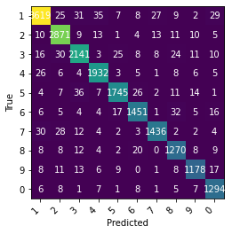

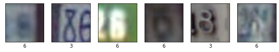

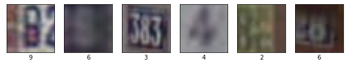

#### Answer 3.2, Activations (4p)

- Retrieve and visualize the activations for one example
- For every filter for different convolutional layers (at different depths in the network).
- Give an explanation. Is your model indeed learning something useful?
  - Should detect edges etc in first layers, higher-order object (e.g. interesting regions) in deeper layers.

[output not shown]

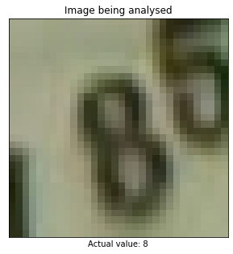

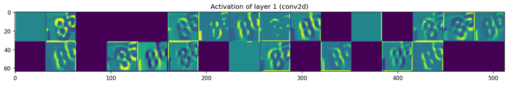

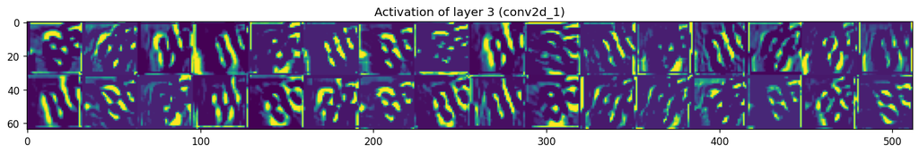

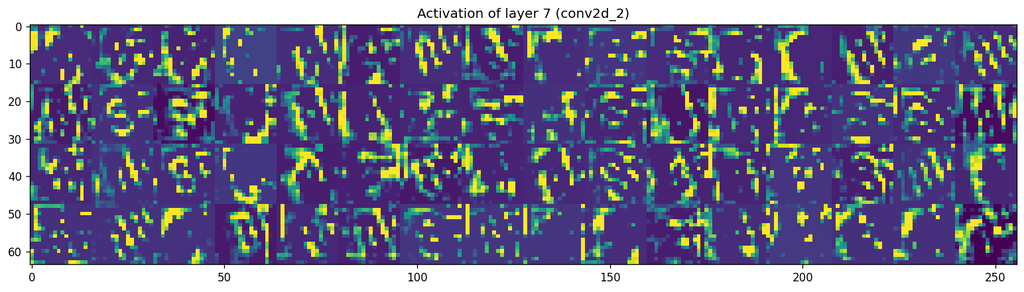

#### Answer 3.3, Class activation map (4p)

- Show a class activation map for your last convolutional layer
- Superimpose the activation map over the image, or plot side by side
  - Should make sense, detect interesting regions to classify the number

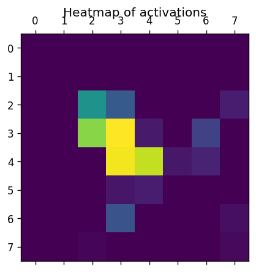

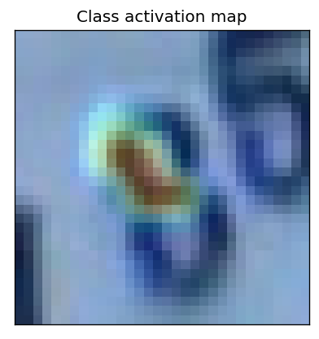

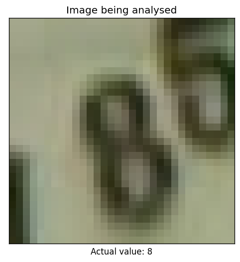

```
def plot_3_3():
    # We first clear the K session
    K.clear_session()
    # We load the model
    model = load_model_from_file(base_dir, "model_2_2")

    # We get our image tensor and expand the dimension
    X_test_gray = rgb2gray(X_test)
    img_tensor = X_test_gray[0]
    img_tensor = np.expand_dims(img_tensor, axis=0)

    # We get the last conv layer and first test example
    last_conv_layer = model.get_layer('conv2d_4')

    preds = model.predict(X_test_gray)
    # Sanity check: print(preds[0])

    first_test_output = model.output[:, np.argmax(preds[0])]

    # We get the gradient of the first test output
    grads = K.gradients(first_test_output, last_conv_layer.output)[0]
    # We get the pooled gradient
    pooled_grads = K.mean(grads, axis=(0, 1, 2))
    # We define this iterator function
    iterate = K.function([model.input], [pooled_grads, last_conv_layer.output[0]])
    # We now get the value of the pooled gradients, and the output of the last conv layer on the test example
    pooled_grads_value, conv_layer_output_value = iterate([img_tensor])

    # We get the output value of the convolutional layer by iterating over all elements in the convolutional layer
    for i in range(128):
        conv_layer_output_value[:, :, i] *= pooled_grads_value[i]

    # The channel-wise mean of the resulting feature map
    # is our heatmap of class activation
    heatmap = np.mean(conv_layer_output_value, axis=-1)
    heatmap = np.maximum(heatmap, 0)
    heatmap /= np.max(heatmap)
    plt.matshow(heatmap)
    plt.rcParams['figure.dpi'] = 120
    plt.title("Heatmap of activations")
```

[output cut: 19 more lines]

```
    superimposed_img = heatmap * 0.3 + img

    cv2.imwrite('3_3.jpg', superimposed_img)

    img2 = cv2.imread('3_3.jpg')
    RGB_im = cv2.cvtColor(img2, cv2.COLOR_BGR2RGB)

    plt.rcParams['figure.dpi'] = 120
    plt.imshow(RGB_im)
    plt.title('Class activation map')
    plt.xticks([])
    plt.yticks([])
    plt.show()

    plot_image(X_test[0], 8)
```

#### Answer 4.1, Fast feature extraction (5p)

- Import the VGG16 model, pretrained on ImageNet
- Freeze convolutional base, adds a dense layer
- Consider unfreezing the last few convolutional layers and evaluate whether that works better
  - Check if they do. It is very likely to help.
- Discuss the observed performance
  - Should get around 80% accuracy

[output not shown]

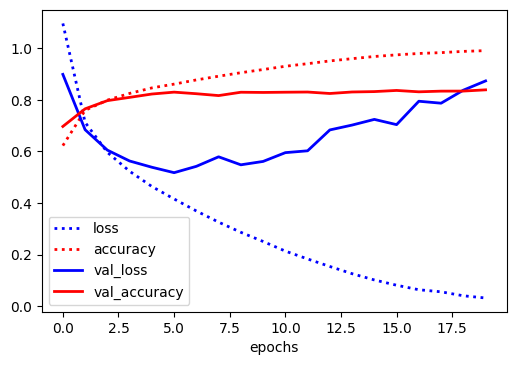

```
Model: "sequential_17"
_________________________________________________________________
Layer (type)                 Output Shape              Param #
=================================================================
vgg16 (Model)                (None, 1, 1, 512)         14714688
_________________________________________________________________
flatten_17 (Flatten)         (None, 512)               0
_________________________________________________________________
dense_34 (Dense)             (None, 512)               262656
_________________________________________________________________
dense_35 (Dense)             (None, 10)                5130
=================================================================
Total params: 14,982,474
Trainable params: 7,347,210
Non-trainable params: 7,635,264
_________________________________________________________________
None
def build_model_4_1():
    # Get the base model with image net as weight, we do not want the top
    base_model = VGG16(include_top=False, weights='imagenet', input_shape=(32, 32, 3))

    # Create the model
    model = models.Sequential()
    # Add the VGG 16 base
    model.add(base_model)
    # We need to flatten
    model.add(layers.Flatten())
    # Add our own layers
    model.add(layers.Dense(512, activation='relu'))

    # End with a softmax layer
    model.add(layers.Dense(10, activation='softmax'))
    # We set trainable to true, so that we can freeze certain layers
    base_model.trainable = True

    # Select which layers to unfreeze
    for layer in base_model.layers:
        # We unfreeze the last three layers, freeze the others
        if layer.name == 'block5_conv1' or layer.name == 'block5_conv2' or layer.name == 'block5_conv3':
            layer.trainable = True
        else:
            layer.trainable = False

    # Get a summary
    model.summary()

    # Compile with known optimisers
    model.compile(optimizer=optimizers.Adagrad(lr=0.01),
              loss='categorical_crossentropy',
              metrics=['accuracy'])

    # Return the model
    return model
```

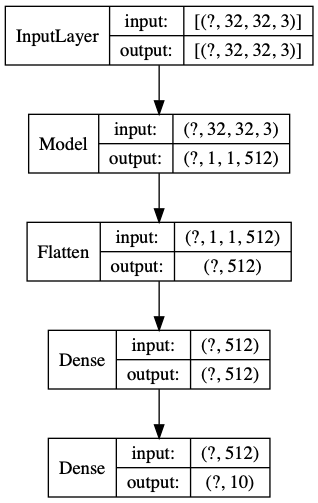

#### Answer 4.2, Embeddings (5p)

- Generate embeddings with the trained convolutional part of model_4_1 (without the dense layer)
- Embed the training and test data and store them to disk
- Build and evaluate a pipeline on the embedded data
  - Check if pipeline makes sense (e.g. use models that can handle many dimensions)
- Describe what you did and what you observed (max 800 chars).
  - Consider different models, preprocessing, tuning, etc.
  - Check performance (see original Submission.html) when in doubt. We did not run all the evaluations because it takes too long, and the output is ill-defined.

[output not shown]

```
Running time: 54.36 seconds
Last modified: May 26, 2020
scikit-learn version: 0.23.1
```